# IE2152 Statistics for IE Project Final Project

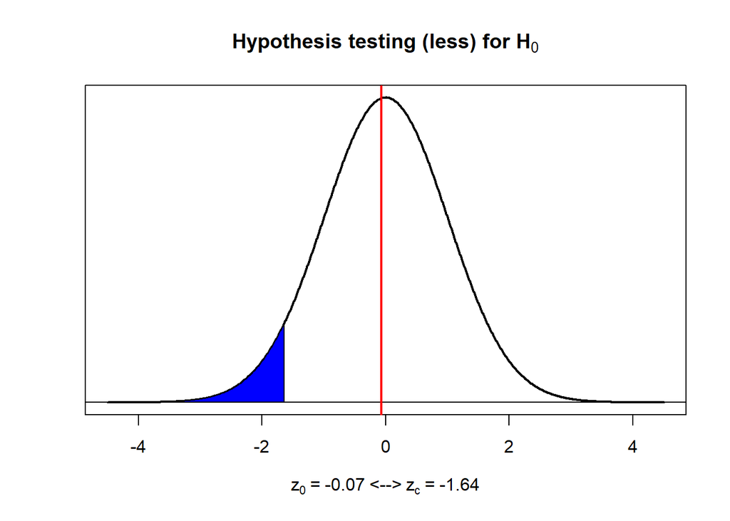

```r
#Use our plotmean.hypothesis function to plot the hypothesis test
plotmean.hypothesis(z1,zc,n,type='z',alt='less')
```

```r
"TEST FOR PERSONNEL EXPENDITURES"
```

```
## [1] "TEST FOR PERSONNEL EXPENDITURES"
```

```r
#Define true parameter value and delta, and calculate power of the test with pwr.norm.test function:
mu02 <- 380000000.0
delta1 <- mu02-mu1; delta1
```

```
## [1] -20000000
```

```r
pwrNorm1 <- pwr.norm.test(delta1/sigma1,n,alpha,power=NULL,alt='less'); pwrNorm1
```

```
##
##      Mean power calculation for normal distribution with known variance
##
##               d = -0.03608
##               n = 42
##       sig.level = 0.05
##           power = 0.07911
##     alternative = less
```

```r
beta1 <- 1-pwrNorm1$power; beta1
```

```
## [1] 0.9209
```

```r
power1 <- 1-beta1; power1
```

```
## [1] 0.07911
```

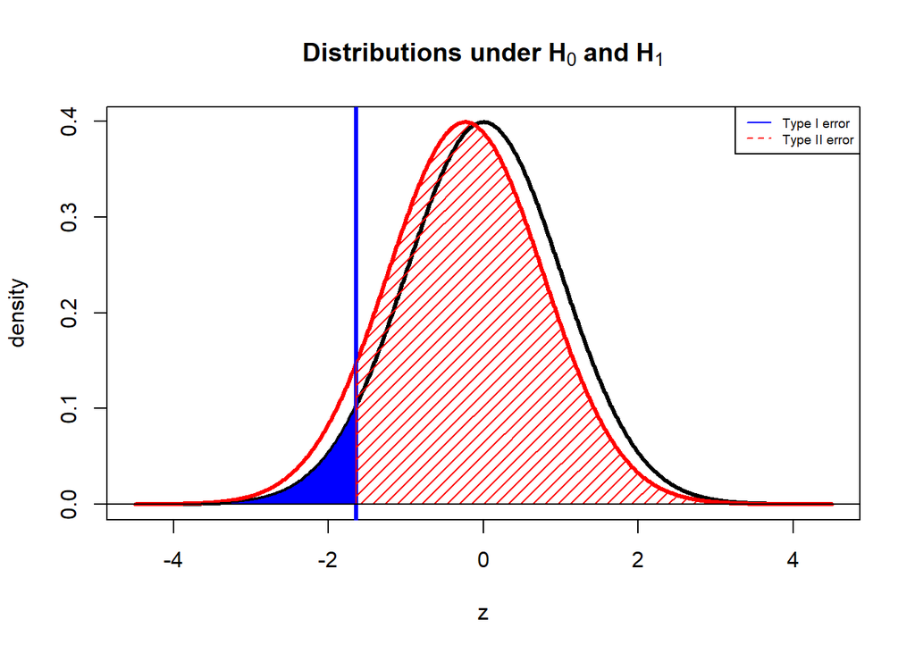

```r
plotmean.beta(sigma1,zc,delta1,n,type='z',alt='less')
```

```r
"FOR OTHER CURRENT EXPENDITURES"
```

```
## [1] "FOR OTHER CURRENT EXPENDITURES"
```

```r
#We want to test the null hypothesis H0: mu=80000000.0 against the less-than one sided alternative using critical value approach
#Define problem data
n<-42       #sample size
mu2<-80000000.0 #hypothesized value
sigma2<-sd(data_22$OCE)    #population standard deviation
xbar2<-mean(data_22$OCE)    #sample mean
alpha<-0.05   #significance level
#Calculate the critical value at 0.05 significance level
zc<-qnorm(alpha); zc
```

```
## [1] -1.645
```

```r
#Calculate the test statistic Z0:
z2<-(xbar2-mu2)/(sigma2/sqrt(n)); z2
```

```
## [1] -0.4354
```

```r
#Use our test.critical function to give the decision
testmean.cv(zc,z2,mu2,alpha,alt="less",theta="mu")
```

```
## [1] "H0: mu = 80000000 is not rejected at 0.05 significance level"
```

```r
###We want to test the null hypothesis H0: mu=80000000.0 against the less-than one sided alternative using p-value approach
#We can use the zsum.test() function from the BSDA package to test the null hypothesis.
zsum.test(mean.x=xbar2, sigma.x=sigma2, n.x=n, alt='less', mu=mu2,conf.level=0.95)
```

```
##
##  One-sample z-Test
##
## data:  Summarized x
## z = -0.44, p-value = 0.3
## alternative hypothesis: true mean is less than 80000000
## 95 percent confidence interval:
##        NA 99355709
## sample estimates:
## mean of x
##  73032098
```

```r
#For manual calculation, calculate the p-value
pval2<-pnorm(z2); pval2
```

```
## [1] 0.3316
```

```r
#Use our test.pval function to give the decision
test.pval(pval2,mu2,alpha,theta="mu")
```

```
## [1] "H0: mu = 80000000 is not rejected at 0.05 significance level"
```

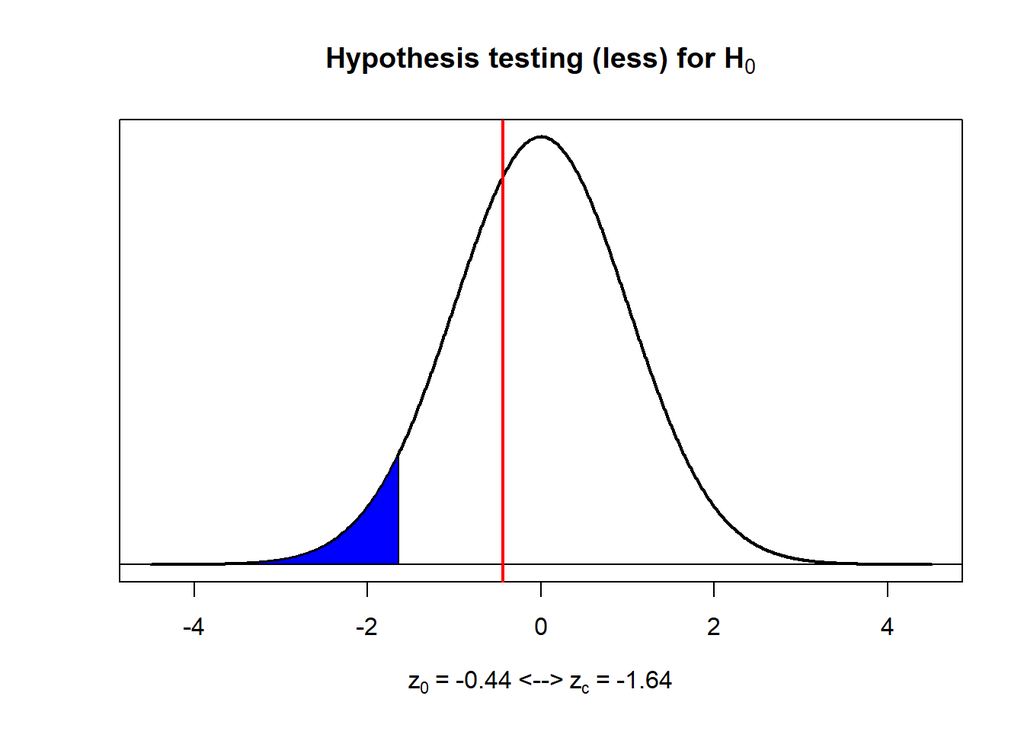

```r
#Use our plotmean.hypothesis function to plot the hypothesis test
plotmean.hypothesis(z2,zc,n,type='z',alt='less')
```

```r
"TEST FOR OTHER CURRENT EXPENDITURES"
```

```
## [1] "TEST FOR OTHER CURRENT EXPENDITURES"
```

```r
#Define true parameter value and delta, and calculate power of the test with pwr.norm.test function:
mu03 <- 76000000.0
delta2 <- mu03-mu2; delta2
```

```
## [1] -4000000
```

```r
pwrNorm2 <- pwr.norm.test(delta2/sigma2,n,alpha,power=NULL,alt='less'); pwrNorm2
```

```
##
##      Mean power calculation for normal distribution with known variance
##
##               d = -0.03857
##               n = 42
##       sig.level = 0.05
##           power = 0.08152
##     alternative = less
```

```r
beta2 <- 1-pwrNorm2$power; beta2
```

```
## [1] 0.9185
```

```r
power2 <- 1-beta2; power2
```

```
## [1] 0.08152
```

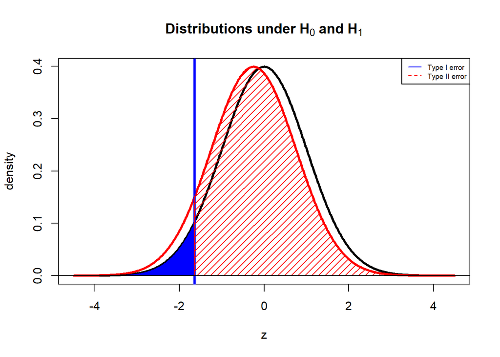

```r
plotmean.beta(sigma2,zc,delta2,n,type='z',alt='less')
```

```r
"FOR DEFENCE"
```

```
## [1] "FOR DEFENCE"
```

```r
#We want to test the null hypothesis H0: mu=70000000.0 against the less-than one sided alternative using critical value approach
#Define problem data
n<-42       #sample size
mu3<-70000000.0 #hypothesized value
sigma3<-sd(data_22$D)    #population standard deviation
xbar3<-mean(data_22$D)    #sample mean
alpha<-0.05   #significance level
#Calculate the critical value at 0.05 significance level
zc<-qnorm(alpha); zc
```

```
## [1] -1.645
```

```r
#Calculate the test statistic Z0:
z3<-(xbar3-mu3)/(sigma3/sqrt(n)); z3
```

```
## [1] -0.08442
```

```r
#Use our test.critical function to give the decision
testmean.cv(zc,z3,mu3,alpha,alt="less",theta="mu")
```

```
## [1] "H0: mu = 70000000 is not rejected at 0.05 significance level"
```

```r
###We want to test the null hypothesis H0: mu=70000000.0 against the less-than one sided alternative using p-value approach
#We can use the zsum.test() function from the BSDA package to test the null hypothesis.
zsum.test(mean.x=xbar3, sigma.x=sigma3, n.x=n, alt='less', mu=mu3,conf.level=0.95)
```

```
##
##  One-sample z-Test
##
## data:  Summarized x
## z = -0.084, p-value = 0.5
## alternative hypothesis: true mean is less than 70000000
## 95 percent confidence interval:
##        NA 92019101
## sample estimates:
## mean of x
##  68808754
```

```r
#For manual calculation, calculate the p-value
pval3<-pnorm(z3); pval3
```

```
## [1] 0.4664
```

```r
#Use our test.pval function to give the decision
test.pval(pval3,mu3,alpha,theta="mu")
```

```
## [1] "H0: mu = 70000000 is not rejected at 0.05 significance level"
```

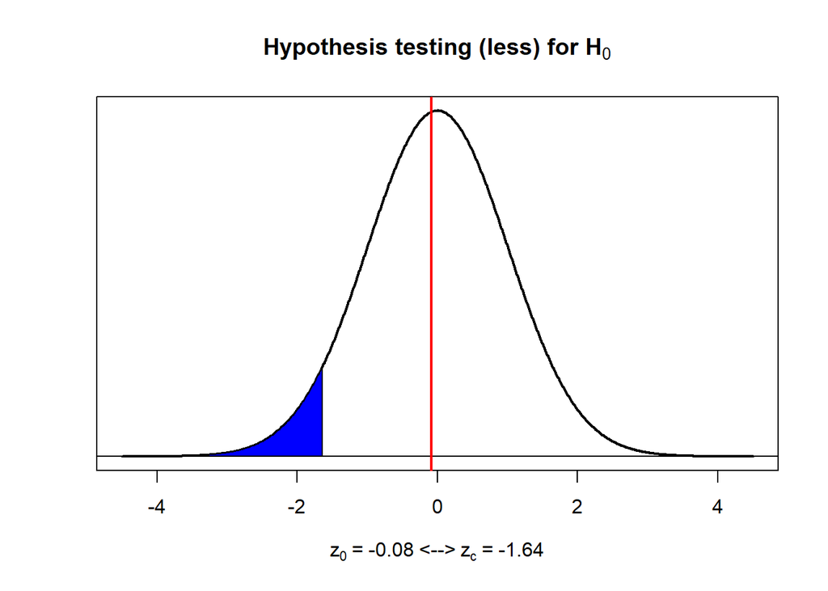

```r
#Use our plotmean.hypothesis function to plot the hypothesis test
plotmean.hypothesis(z3,zc,n,type='z',alt='less')
```

```r
"TEST FOR DEFENCE"
```

```
## [1] "TEST FOR DEFENCE"
```

```r
#Define true parameter value and delta, and calculate power of the test with pwr.norm.test function:
mu04 <- 69000000.0
delta3 <- mu04-mu3; delta3
```

```
## [1] -1000000
```

```r
pwrNorm3 <- pwr.norm.test(delta3/sigma3,n,alpha,power=NULL,alt='less'); pwrNorm3
```

```
##
##      Mean power calculation for normal distribution with known variance
##
##               d = -0.01094
##               n = 42
##       sig.level = 0.05
##           power = 0.05775
##     alternative = less
```

```r
beta3 <- 1-pwrNorm3$power; beta3
```

```
## [1] 0.9423
```

```r
power3 <- 1-beta3; power3
```

```
## [1] 0.05775
```

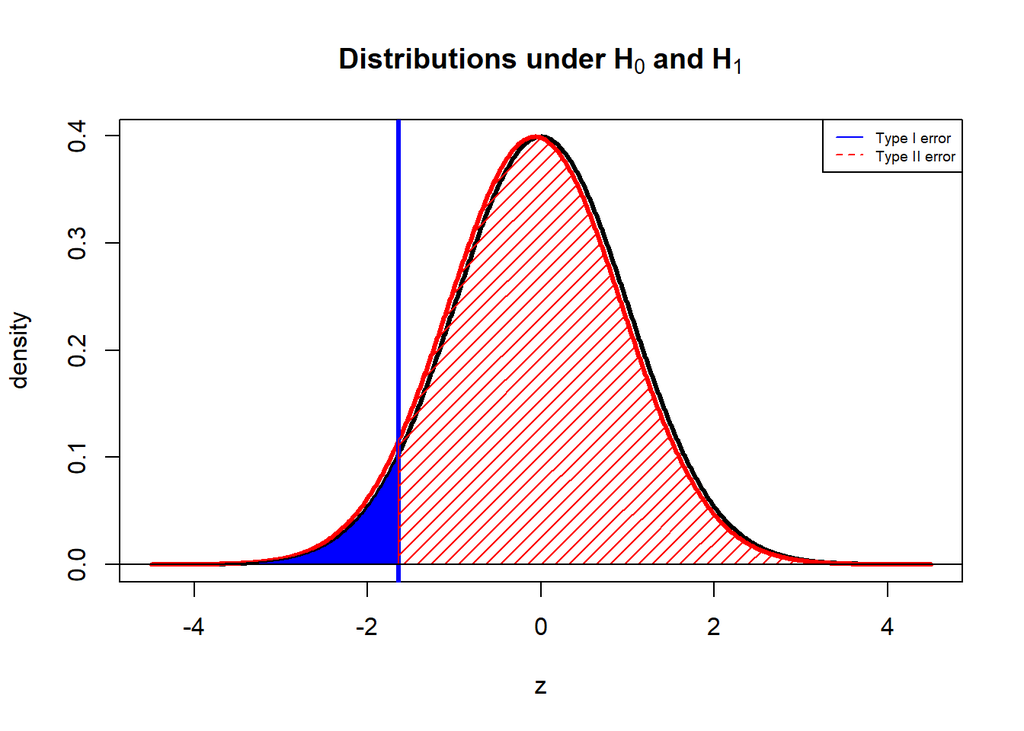

```r
plotmean.beta(sigma3,zc,delta3,n,type='z',alt='less')
```

```r
"FOR GNP"
```

```
## [1] "FOR GNP"
```

```r
#We want to test the null hypothesis H0: mu=3000000000 against the less-than one sided alternative using critical value approach
#Define problem data
n<-42       #sample size
mu4<-3000000000 #hypothesized value
sigma4<-sd(data_22$GNP)    #population standard deviation
xbar4<-mean(data_22$GNP)    #sample mean
alpha<-0.05   #significance level
#Calculate the critical value at 0.05 significance level
zc<-qnorm(alpha); zc
```

```
## [1] -1.645
```

```r
#Calculate the test statistic Z0:
z4<-(xbar4-mu4)/(sigma4/sqrt(n)); z4
```

```
## [1] -0.1674
```

```r
#Use our test.critical function to give the decision
testmean.cv(zc,z4,mu4,alpha,alt="less",theta="mu")
```

```
## [1] "H0: mu = 3000000000 is not rejected at 0.05 significance level"
```

```r
###We want to test the null hypothesis H0: mu=3000000000 against the less-than one sided alternative using p-value approach
#We can use the zsum.test() function from the BSDA package to test the null hypothesis.
zsum.test(mean.x=xbar4, sigma.x=sigma4, n.x=n, alt='less', mu=mu4,conf.level=0.95)
```

```
##
##  One-sample z-Test
##
## data:  Summarized x
## z = -0.17, p-value = 0.4
## alternative hypothesis: true mean is less than 3000000000
## 95 percent confidence interval:
##          NA 4015558347
## sample estimates:
##  mean of x
## 2884909571
```

```r
#For manual calculation, calculate the p-value
pval4<-pnorm(z4); pval4
```

```
## [1] 0.4335
```

```r
#Use our test.pval function to give the decision
test.pval(pval4,mu4,alpha,theta="mu")
```

```
## [1] "H0: mu = 3000000000 is not rejected at 0.05 significance level"
```

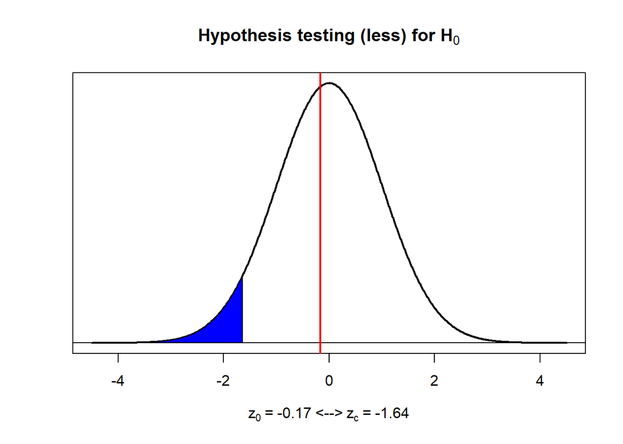

```r
#Use our plotmean.hypothesis function to plot the hypothesis test
plotmean.hypothesis(z4,zc,n,type='z',alt='less')
```

```r
"TEST FOR GNP"
```

```
## [1] "TEST FOR GNP"
```

```r
#Define true parameter value and delta, and calculate power of the test with pwr.norm.test function:
mu05 <- 2900000000
delta4 <- mu05-mu4; delta4
```

```
## [1] -100000000
```

```r
pwrNorm4 <- pwr.norm.test(delta4/sigma4,n,alpha,power=NULL,alt='less'); pwrNorm4
```

```
##
##      Mean power calculation for normal distribution with known variance
##
##               d = -0.02245
##               n = 42
##       sig.level = 0.05
##           power = 0.06689
##     alternative = less
```

```r
beta4 <- 1-pwrNorm4$power; beta4
```

```
## [1] 0.9331
```

```r
power4 <- 1-beta4; power4
```

```
## [1] 0.06689
```

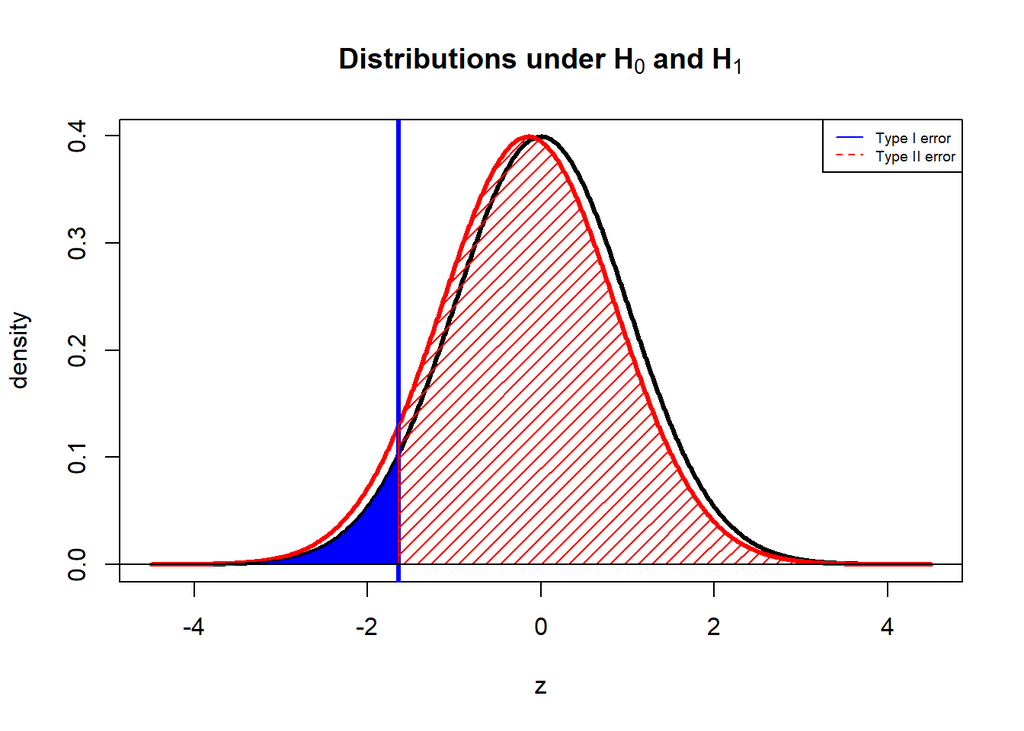

```r
plotmean.beta(sigma4,zc,delta4,n,type='z',alt='less')
```

…

#### 3.2.2.2. Hypothesis Tests on the Population Variance of a Single Sample

Chi-squared test is used to conduct Hypothesis Tests. It is a method used to test whether the expected frequencies are actually the same as the expected frequency. …

```r
#Write your codes here. Their results will appear after knitting the markdown file.
"FOR CURRENT EXPENDITURES"
```

```
## [1] "FOR CURRENT EXPENDITURES"
```

```r
#In order to test the null hypothesis H0: sigma^2=450000000000000000 against the one-sided (greater) alternative using critical value approach
n<-42                       #sample size
var7<-var(data_22$CE);var7       #sample variance
```

```
## [1] 432804216879521536
```

```r
sigmasq7<-450000000000000000          #hypothesized value
alpha<-0.05                            #significance level

#The critical values at 0.05 significance level was calculated
chisqc7<-qchisq(1-alpha,df=n-1); chisqc7
```

```
## [1] 56.94
```

```r
#Also,the critical value by setting lower=FALSE is calculated becaues we the upper tail is needed.
chisqc7<-qchisq(alpha,df=n-1,lower=F); chisqc7
```

```
## [1] 56.94
```

```r
#Then,the test statistic was calculated:
chisq7<-(n-1)*var7/sigmasq7; chisq7
```

```
## [1] 39.43
```

```r
#The test statistic with the critical values was compared and then a decision was made.
testvar.cv(cvup=chisqc7,cvlo=NULL,chisq7,sigmasq7,alpha,alt="g")
```

```
## [1] "H0: sigma^2 = 450000000000000000 is not rejected at 0.05 significance level"
```

```r
# The p-value approach was done in order to test the null hypothesis H0: sigma^2=450000000000000000 against the one-sided (greater) alternative
pval7<-1-pchisq(chisq7,df=n-1); pval7
```

```
## [1] 0.5404
```

```r
pval7<-pchisq(chisq7,df=n-1,lower=F); pval7
```

```
## [1] 0.5404
```

```r
#P-value with the significance level was compared and then a decision was made.
test.pval(pval7,sigmasq7,alpha,theta="sigma^2")
```

```
## [1] "H0: sigma^2 = 450000000000000000 is not rejected at 0.05 significance level"
```

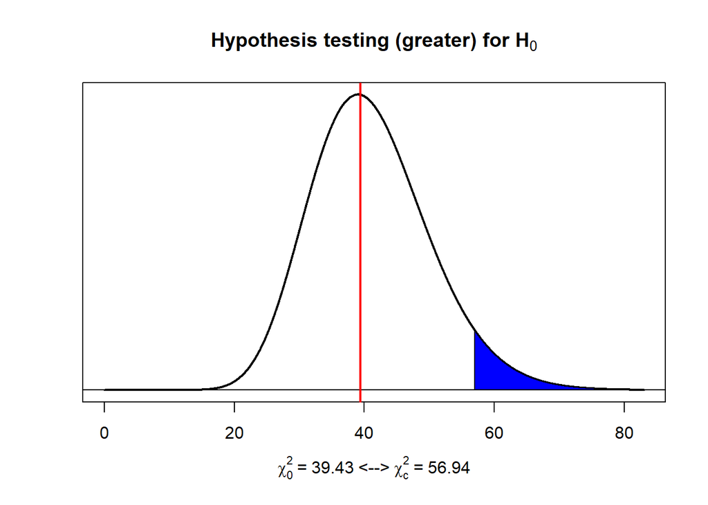

```r
# plotvar.hypothesis function was used in order to plot the hypothesis test.
plotvar.hypothesis(chisq7,alpha,n-1,type='chisq',alt='g')
```

```r
"FOR PERSONNEL EXPENDITURES"
```

```
## [1] "FOR PERSONNEL EXPENDITURES"
```

```r
#In order to test the null hypothesis H0: sigma^2=350000000000000000 against the one-sided (greater) alternative using critical value approach
n<-42                       #sample size
var8<-var(data_22$PE);var8       #sample variance
```

```
## [1] 307348250641565056
```

```r
sigmasq8<-350000000000000000          #hypothesized value
alpha<-0.05                            #significance level

#The critical values at 0.05 significance level was calculated
chisqc8<-qchisq(1-alpha,df=n-1); chisqc8
```

```
## [1] 56.94
```

```r
#Also,the critical value by setting lower=FALSE is calculated becaues we the upper tail is needed.
chisqc8<-qchisq(alpha,df=n-1,lower=F); chisqc8
```

```
## [1] 56.94
```

```r
#Then,the test statistic was calculated:
chisq8<-(n-1)*var8/sigmasq8; chisq8
```

```
## [1] 36
```

```r
#The test statistic with the critical values was compared and then a decision was made.
testvar.cv(cvup=chisqc8,cvlo=NULL,chisq8,sigmasq8,alpha,alt="g")
```

```
## [1] "H0: sigma^2 = 350000000000000000 is not rejected at 0.05 significance level"
```

```r
# The p-value approach was done in order to test the null hypothesis H0: sigma^2=450000000000000000 against the one-sided (greater) alternative
pval8<-1-pchisq(chisq8,df=n-1); pval8
```

```
## [1] 0.692
```

```r
pval8<-pchisq(chisq8,df=n-1,lower=F); pval8
```

```
## [1] 0.692
```

```r
#P-value with the significance level was compared and then a decision was made.
test.pval(pval8,sigmasq8,alpha,theta="sigma^2")
```

```
## [1] "H0: sigma^2 = 350000000000000000 is not rejected at 0.05 significance level"
```

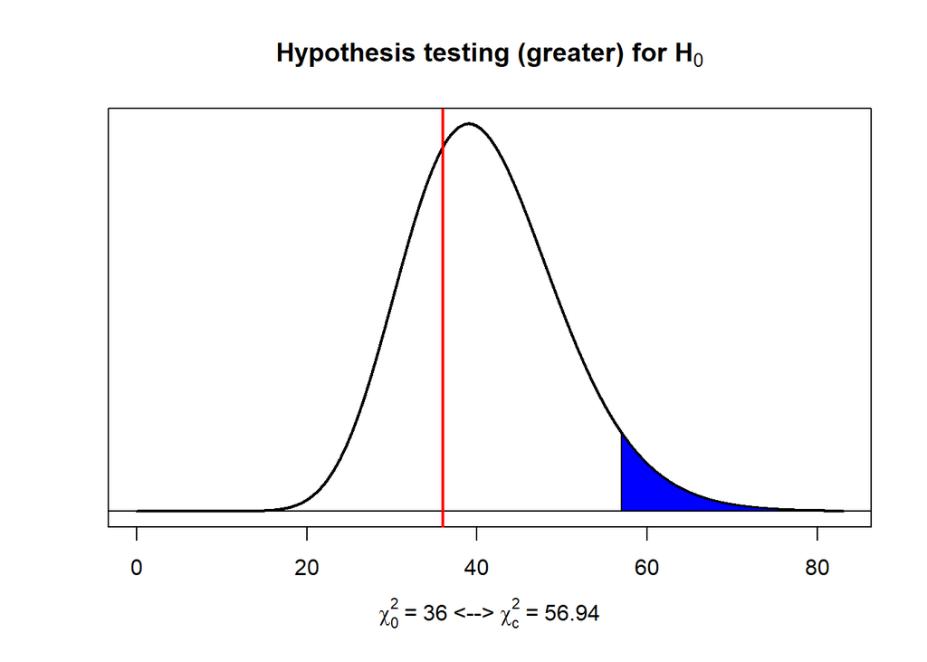

```r
# plotvar.hypothesis function was used in order to plot the hypothesis test.
plotvar.hypothesis(chisq8,alpha,n-1,type='chisq',alt='g')
```

```r
"FOR OTHER CURRENT EXPENDITURES"
```

```
## [1] "FOR OTHER CURRENT EXPENDITURES"
```

```r
#In order to test the null hypothesis H0: sigma^2=12000000000000000 against the one-sided (greater) alternative using critical value approach
n<-42                       #sample size
var9<-var(data_22$OCE);var9       #sample variance
```

```
## [1] 10756865022613600
```

```r
sigmasq9<-12000000000000000         #hypothesized value
alpha<-0.05                            #significance level

#The critical values at 0.05 significance level was calculated
chisqc9<-qchisq(1-alpha,df=n-1); chisqc9
```

```
## [1] 56.94
```

```r
#Also,the critical value by setting lower=FALSE is calculated becaues we the upper tail is needed.
chisqc9<-qchisq(alpha,df=n-1,lower=F); chisqc9
```

```
## [1] 56.94
```

```r
#Then,the test statistic was calculated:
chisq9<-(n-1)*var9/sigmasq9; chisq9
```

```
## [1] 36.75
```

```r
#The test statistic with the critical values was compared and then a decision was made.
testvar.cv(cvup=chisqc9,cvlo=NULL,chisq9,sigmasq9,alpha,alt="g")
```

```
## [1] "H0: sigma^2 = 12000000000000000 is not rejected at 0.05 significance level"
```

```r
# The p-value approach was done in order to test the null hypothesis H0: sigma^2=12000000000000000 against the one-sided (greater) alternative
pval9<-1-pchisq(chisq9,df=n-1); pval9
```

```
## [1] 0.6598
```

```r
pval9<-pchisq(chisq9,df=n-1,lower=F); pval9
```

```
## [1] 0.6598
```

```r
#P-value with the significance level was compared and then a decision was made.
test.pval(pval9,sigmasq9,alpha,theta="sigma^2")
```

```
## [1] "H0: sigma^2 = 12000000000000000 is not rejected at 0.05 significance level"
```

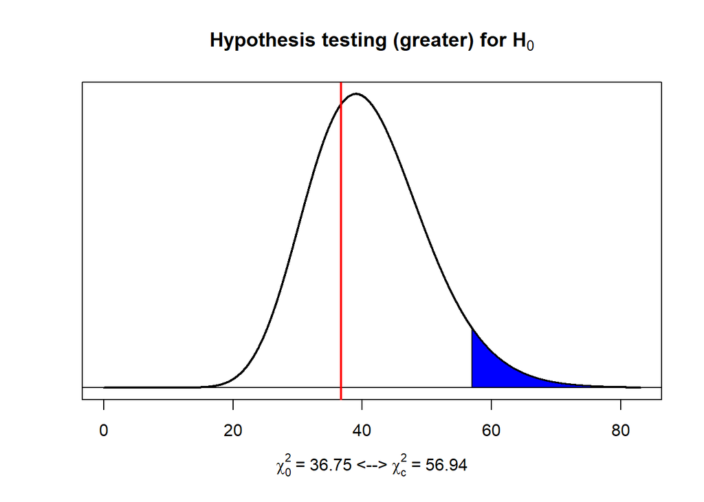

```r
# plotvar.hypothesis function was used in order to plot the hypothesis test.
plotvar.hypothesis(chisq9,alpha,n-1,type='chisq',alt='g')
```

```r
"FOR DEFENCE"
```

```
## [1] "FOR DEFENCE"
```

```r
#In order to test the null hypothesis H0: sigma^2=8500000000000000 against the one-sided (greater) alternative using critical value approach
n<-42                       #sample size
var10<-var(data_22$D);var10       #sample variance
```

```
## [1] 8362922193236486
```

```r
sigmasq10<-8500000000000000         #hypothesized value
alpha<-0.05                            #significance level

#The critical values at 0.05 significance level was calculated
chisqc10<-qchisq(1-alpha,df=n-1); chisqc10
```

```
## [1] 56.94
```

```r
#Also,the critical value by setting lower=FALSE is calculated becaues we the upper tail is needed.
chisqc10<-qchisq(alpha,df=n-1,lower=F); chisqc10
```

```
## [1] 56.94
```

```r
#Then,the test statistic was calculated:
chisq10<-(n-1)*var10/sigmasq10; chisq10
```

```
## [1] 40.34
```

```r
#The test statistic with the critical values was compared and then a decision was made.
testvar.cv(cvup=chisqc10,cvlo=NULL,chisq10,sigmasq10,alpha,alt="g")
```

```
## [1] "H0: sigma^2 = 8500000000000000 is not rejected at 0.05 significance level"
```

```r
# The p-value approach was done in order to test the null hypothesis H0: sigma^2=8500000000000000 against the one-sided (greater) alternative
pval10<-1-pchisq(chisq10,df=n-1); pval10
```

```
## [1] 0.4998
```

```r
pval10<-pchisq(chisq10,df=n-1,lower=F); pval10
```

```
## [1] 0.4998
```

```r
#P-value with the significance level was compared and then a decision was made.
test.pval(pval10,sigmasq10,alpha,theta="sigma^2")
```

```
## [1] "H0: sigma^2 = 8500000000000000 is not rejected at 0.05 significance level"
```

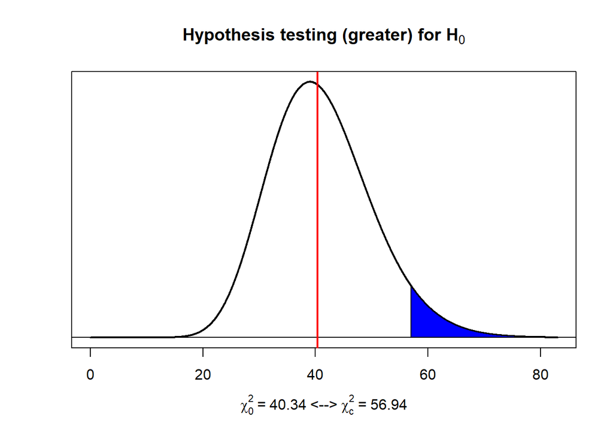

```r
# plotvar.hypothesis function was used in order to plot the hypothesis test.
plotvar.hypothesis(chisq10,alpha,n-1,type='chisq',alt='g')
```

```r
"FOR GNP"
```

```
## [1] "FOR GNP"
```

```r
#In order to test the null hypothesis H0: sigma^2=21000000000000000000 against the one-sided (greater) alternative using critical value approach
n<-42                       #sample size
var11<-var(data_22$GNP);var11       #sample variance
```

```
## [1] 19844959216553959424
```

```r
sigmasq11<-21000000000000000000        #hypothesized value
alpha<-0.05                            #significance level

#The critical values at 0.05 significance level was calculated
chisqc11<-qchisq(1-alpha,df=n-1); chisqc11
```

```
## [1] 56.94
```

```r
#Also,the critical value by setting lower=FALSE is calculated becaues we the upper tailis needed.
chisqc11<-qchisq(alpha,df=n-1,lower=F); chisqc11
```

```
## [1] 56.94
```

```r
#Then,the test statistic was calculated:
chisq11<-(n-1)*var11/sigmasq11; chisq11
```

```
## [1] 38.74
```

```r
#The test statistic with the critical values was compared and then a decision was made.
testvar.cv(cvup=chisqc10,cvlo=NULL,chisq11,sigmasq11,alpha,alt="g")
```

```
## [1] "H0: sigma^2 = 21000000000000000000 is not rejected at 0.05 significance level"
```

```r
# The p-value approach was done in order to test the null hypothesis H0: sigma^2=21000000000000000000 against the one-sided (greater) alternative
pval11<-1-pchisq(chisq11,df=n-1); pval11
```

```
## [1] 0.5713
```

```r
pval11<-pchisq(chisq11,df=n-1,lower=F); pval11
```

```
## [1] 0.5713
```

```r
#P-value with the significance level was compared and then a decision was made.
test.pval(pval11,sigmasq11,alpha,theta="sigma^2")
```

```
## [1] "H0: sigma^2 = 21000000000000000000 is not rejected at 0.05 significance level"
```

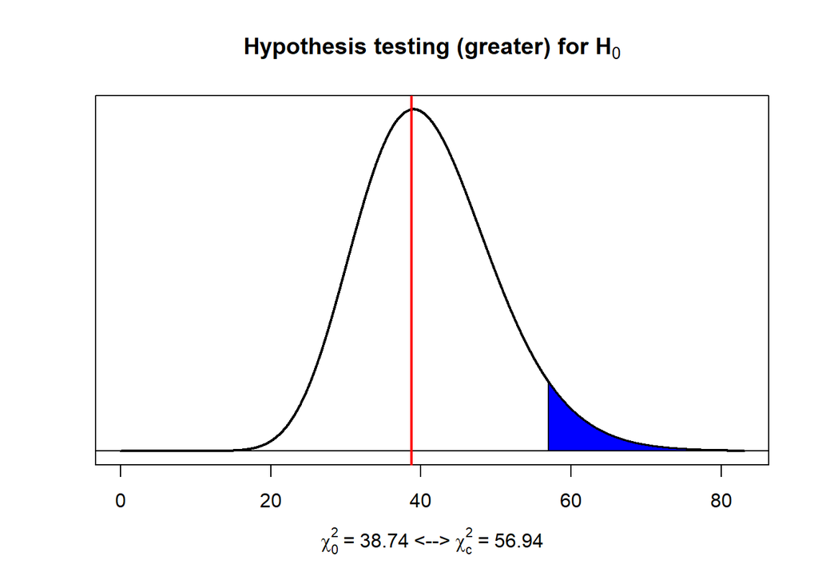

```r
# plotvar.hypothesis function was used in order to plot the hypothesis test.
plotvar.hypothesis(chisq11,alpha,n-1,type='chisq',alt='g')
```

…

#### 3.2.2.3. Hypothesis Tests on the Difference of Population Means/Proportions of Two Samples

Difference between population means is determined, population standard deviation is unknown and n>=30 so z test is applied for hypothesis tests. …

```r
#Write your codes here. Their results will appear after knitting the markdown file.

"FOR PERSONNEL EXPENDITURES AND OTHER CURRENT EXPENDITURES"
```

```
## [1] "FOR PERSONNEL EXPENDITURES AND OTHER CURRENT EXPENDITURES"
```

```r
#We want to test the null hypothesis H0: mu1-mu2=0 against the greater than one-sided alternative using critical value approach
#Define problem data
n1<-42         #sample size from population 1
n2<-42         #sample size from population 2
delta0<-0      #hypothesized value
sigma1<-sd(data_22$PE)      #sample 1 standard deviation
sigma2<-sd(data_22$OCE)      #sample 2 standard deviation
xbar18<- mean(data_22$PE)     #sample mean from population 1
xbar19<-mean(data_22$OCE)     #sample mean from population 2
alpha<-0.05    #significance level

#We can use the zsum.test() function from the BSDA package to test the null hypothesis.
zsum.test(xbar18, sigma1, n1, xbar19, sigma2, n2, alt='g', conf.level=0.95)
```

```
##
##  Two-sample z-Test
##
## data:  Summarized x and y
## z = 3.7, p-value = 0.0001
## alternative hypothesis: true difference in means is greater than 0
## 95 percent confidence interval:
##  177928290        NA
## sample estimates:
## mean of x mean of y
## 394109263  73032098
```

```r
#For manual calculation, calculate the standard error of the difference in means
sed<-sqrt(sigma1^2/n1+sigma2^2/n2);sed
```

```
## [1] 87028336
```

```r
#Calculate the critical value at 0.05 significance level
zc<-qnorm(1-alpha); zc
```

```
## [1] 1.645
```

```r
#Calculate the test statistic Z0 and use our testmean.cv function to give the decision:
z0<-(xbar18-xbar19-delta0)/sed; z0
```

```
## [1] 3.689
```

```r
testmean.cv(zc,z0,delta0,alpha,alt="g",theta="mu1-mu2")
```

```
## [1] "H0: mu1-mu2 = 0 is rejected at 0.05 significance level"
```

```r
#Calculate the p-value and use our test.pval function to give the decision:
pval<-(1-pnorm(z0)); pval
```

```
## [1] 0.0001124
```

```r
test.pval(pval,delta0,alpha,theta="mu1-mu2")
```

```
## [1] "H0: mu1-mu2 = 0 is rejected at 0.05 significance level"
```

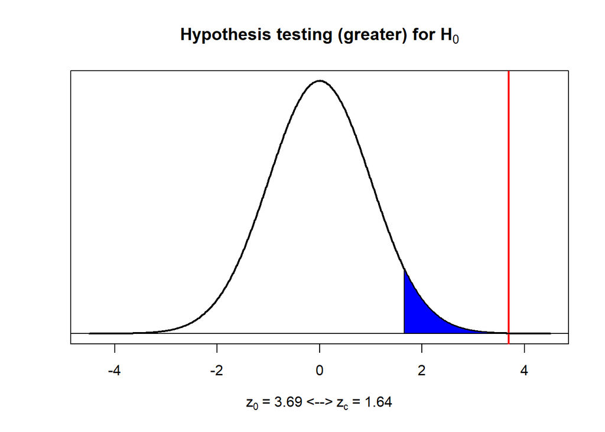

```r
#Use the plot.hypothesis function to plot the hypothesis test
plotmean.hypothesis(z0,zc,type='z',alt='g')
```

```r
#Define true difference in population means, and compute the power of the test with pwr.norm.test function:
delta<-(xbar18-xbar19)
d<-(delta-delta0)/sqrt(sigma1^2+sigma2^2)
pwr.norm.test(d,n1,0.05,alt='g')
```

```
##
##      Mean power calculation for normal distribution with known variance
##
##               d = 0.5693
##               n = 42
##       sig.level = 0.05
##           power = 0.9795
##     alternative = greater
```

```r
#We can also compute the type II error and power of the test manually:
beta <- pnorm(zc-((delta-delta0)/sed)); beta
```

```
## [1] 0.02045
```

```r
power<-1-beta; power
```

```
## [1] 0.9795
```

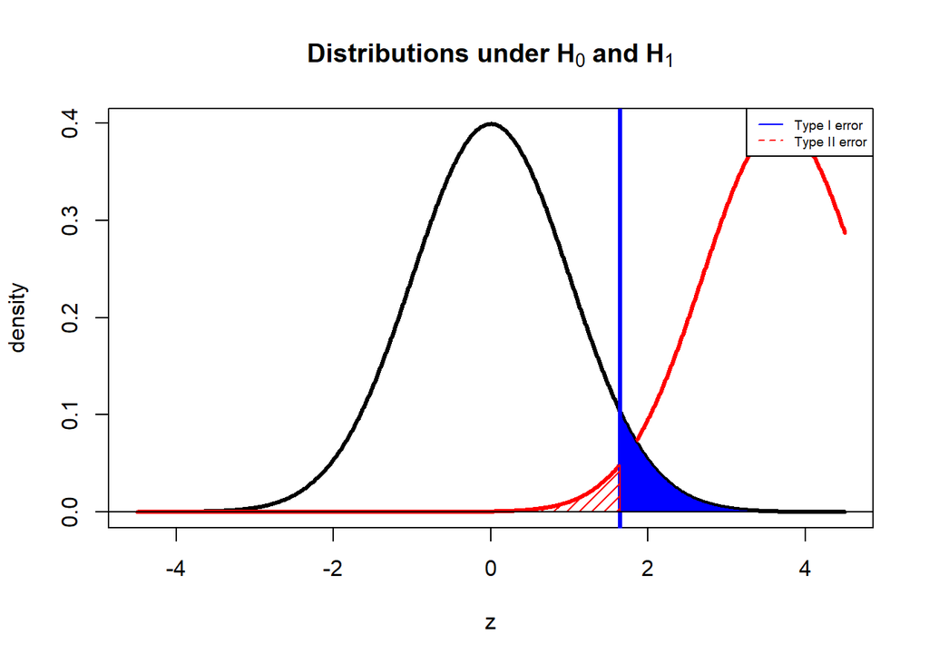

```r
#We can use our plotbeta function with the required parameters:
plotmean.beta(sed,zc,delta,n=1,type='z',alt='g')
```

```r
#In the second part, we need to determine the required sample size
#Again, we can use the pwr.norm.test function as seen below:
pwr.norm.test(d,n=NULL,0.05,power=0.90,alt='g')
```

```
##
##      Mean power calculation for normal distribution with known variance
##
##               d = 0.5693
##               n = 26.43
##       sig.level = 0.05
##           power = 0.9
##     alternative = greater
```

```r
#We can calculate the required sample size also manually.
#The parameters beta and zbeta are determined.
beta2 <- 0.10
zbeta <-qnorm(1-beta2); zbeta
```

```
## [1] 1.282
```

```r
#The required sample size is calculated.
nreq<-((zc+zbeta)/d)^2; nreq
```

```
## [1] 26.43
```

```r
ceiling(nreq)
```

```
## [1] 27
```

```r
"FOR PERSONNEL EXPENDITURES AND DEFENCE"
```

```
## [1] "FOR PERSONNEL EXPENDITURES AND DEFENCE"
```

```r
#We want to test the null hypothesis H0: mu1-mu2=0 against the greater than one-sided alternative using critical value approach
#Define problem data
n1<-42         #sample size from population 1
n2<-42         #sample size from population 2
delta0<-0      #hypothesized value
sigma1<-sd(data_22$PE)      #sample 1 standard deviation
sigma2<-sd(data_22$D)      #sample 2 standard deviation
xbar20<- mean(data_22$PE)     #sample mean from population 1
xbar21<-mean(data_22$D)     #sample mean from population 2
alpha<-0.05    #significance level

#We can use the zsum.test() function from the BSDA package to test the null hypothesis.
zsum.test(xbar20, sigma1, n1, xbar21, sigma2, n2, alt='g', conf.level=0.95)
```

```
##
##  Two-sample z-Test
##
## data:  Summarized x and y
## z = 3.8, p-value = 0.00009
## alternative hypothesis: true difference in means is greater than 0
## 95 percent confidence interval:
##  182691294        NA
## sample estimates:
## mean of x mean of y
## 394109263  68808754
```

```r
#For manual calculation, calculate the standard error of the difference in means
sed<-sqrt(sigma1^2/n1+sigma2^2/n2);sed
```

```
## [1] 86700246
```

```r
#Calculate the critical value at 0.05 significance level
zc<-qnorm(1-alpha); zc
```

```
## [1] 1.645
```

```r
#Calculate the test statistic Z0 and use our testmean.cv function to give the decision:
z0<-(xbar20-xbar21-delta0)/sed; z0
```

```
## [1] 3.752
```

```r
testmean.cv(zc,z0,delta0,alpha,alt="g",theta="mu1-mu2")
```

```
## [1] "H0: mu1-mu2 = 0 is rejected at 0.05 significance level"
```

```r
#Calculate the p-value and use our test.pval function to give the decision:
pval<-(1-pnorm(z0)); pval
```

```
## [1] 0.00008771
```

```r
test.pval(pval,delta0,alpha,theta="mu1-mu2")
```

```
## [1] "H0: mu1-mu2 = 0 is rejected at 0.05 significance level"
```

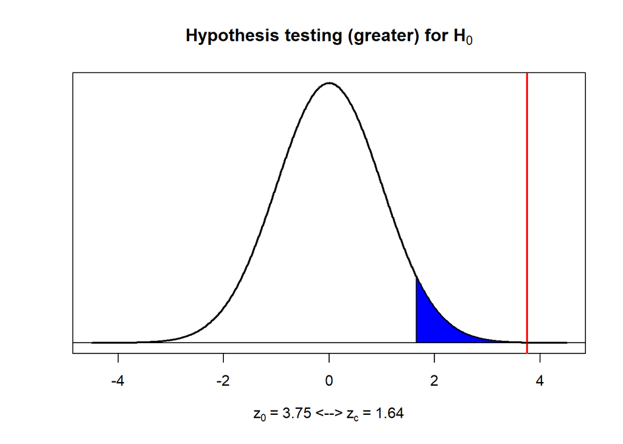

```r
#Use the plot.hypothesis function to plot the hypothesis test
plotmean.hypothesis(z0,zc,type='z',alt='g')
```

```r
#Define true difference in population means, and compute the power of the test with pwr.norm.test function:
delta<-(xbar20-xbar21)
d<-(delta-delta0)/sqrt(sigma1^2+sigma2^2)
pwr.norm.test(d,n1,0.05,alt='g')
```

```
##
##      Mean power calculation for normal distribution with known variance
##
##               d = 0.5789
##               n = 42
##       sig.level = 0.05
##           power = 0.9824
##     alternative = greater
```

```r
#We can also compute the type II error and power of the test manually:
beta <- pnorm(zc-((delta-delta0)/sed)); beta
```

```
## [1] 0.01755
```

```r
power<-1-beta; power
```

```
## [1] 0.9824
```

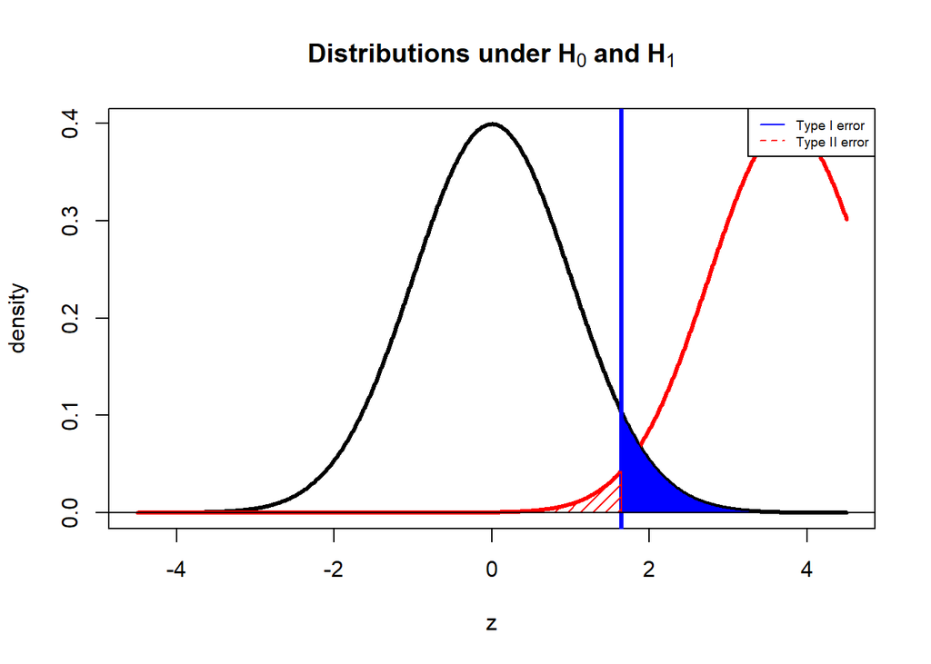

```r
#We can use our plotbeta function with the required parameters:
plotmean.beta(sed,zc,delta,n=1,type='z',alt='g')
```

```r
#In the second part, we need to determine the required sample size
#Again, we can use the pwr.norm.test function as seen below:
pwr.norm.test(d,n=NULL,0.05,power=0.90,alt='g')
```

```
##
##      Mean power calculation for normal distribution with known variance
##
##               d = 0.5789
##               n = 25.55
##       sig.level = 0.05
##           power = 0.9
##     alternative = greater
```

```r
#We can calculate the required sample size also manually.
#The parameters beta and zbeta are determined.
beta2 <- 0.10
zbeta <-qnorm(1-beta2); zbeta
```

```
## [1] 1.282
```

```r
#The required sample size is calculated.
nreq<-((zc+zbeta)/d)^2; nreq
```

```
## [1] 25.55
```

```r
ceiling(nreq)
```

```
## [1] 26
```

```r
"FOR OTHER CURRENT EXPENDITURES AND DEFENCE"
```

```
## [1] "FOR OTHER CURRENT EXPENDITURES AND DEFENCE"
```

```r
#We want to test the null hypothesis H0: mu1-mu2=0 against the greater than one-sided alternative using critical value approach
#Define problem data
n1<-42         #sample size from population 1
n2<-42         #sample size from population 2
delta0<-0      #hypothesized value
sigma1<-sd(data_22$OCE)      #sample 1 standard deviation
sigma2<-sd(data_22$D)      #sample 2 standard deviation
xbar22<- mean(data_22$OCE)     #sample mean from population 1
xbar23<-mean(data_22$D)     #sample mean from population 2
alpha<-0.05    #significance level

#We can use the zsum.test() function from the BSDA package to test the null hypothesis.
zsum.test(xbar22, sigma1, n1, xbar23, sigma2, n2, alt='g', conf.level=0.95)
```

```
##
##  Two-sample z-Test
##
## data:  Summarized x and y
## z = 0.2, p-value = 0.4
## alternative hypothesis: true difference in means is greater than 0
## 95 percent confidence interval:
##  -30871567        NA
## sample estimates:
## mean of x mean of y
##  73032098  68808754
```

```r
#For manual calculation, calculate the standard error of the difference in means
sed<-sqrt(sigma1^2/n1+sigma2^2/n2);sed
```

```
## [1] 21336191
```

```r
#Calculate the critical value at 0.05 significance level
zc<-qnorm(1-alpha); zc
```

```
## [1] 1.645
```

```r
#Calculate the test statistic Z0 and use our testmean.cv function to give the decision:
z0<-(xbar22-xbar23-delta0)/sed; z0
```

```
## [1] 0.1979
```

```r
testmean.cv(zc,z0,delta0,alpha,alt="g",theta="mu1-mu2")
```

```
## [1] "H0: mu1-mu2 = 0 is not rejected at 0.05 significance level"
```

```r
#Calculate the p-value and use our test.pval function to give the decision:
pval<-(1-pnorm(z0)); pval
```

```
## [1] 0.4215
```

```r
test.pval(pval,delta0,alpha,theta="mu1-mu2")
```

```
## [1] "H0: mu1-mu2 = 0 is not rejected at 0.05 significance level"
```

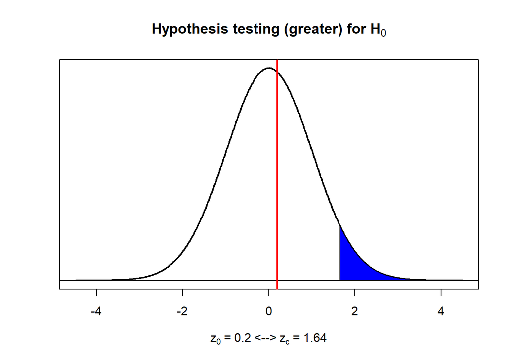

```r
#Use the plot.hypothesis function to plot the hypothesis test
plotmean.hypothesis(z0,zc,type='z',alt='g')
```

```r
#Define true difference in population means, and compute the power of the test with pwr.norm.test function:
delta<-(xbar22-xbar23)
d<-(delta-delta0)/sqrt(sigma1^2+sigma2^2)
pwr.norm.test(d,n1,0.05,alt='g')
```

```
##
##      Mean power calculation for normal distribution with known variance
##
##               d = 0.03054
##               n = 42
##       sig.level = 0.05
##           power = 0.07396
##     alternative = greater
```

```r
#We can also compute the type II error and power of the test manually:
beta <- pnorm(zc-((delta-delta0)/sed)); beta
```

```
## [1] 0.926
```

```r
power<-1-beta; power
```

```
## [1] 0.07396
```

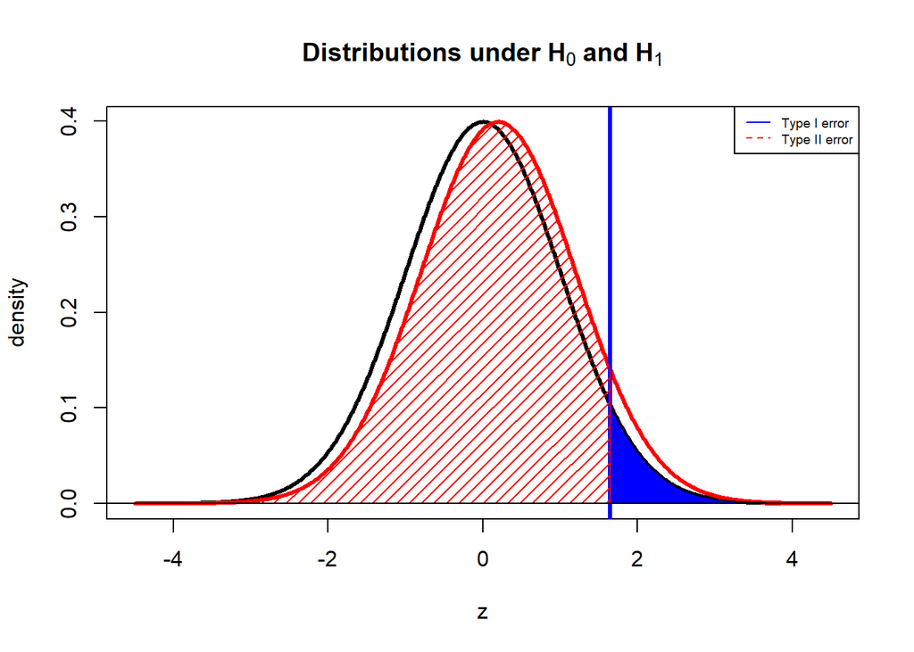

```r
#We can use our plotbeta function with the required parameters:
plotmean.beta(sed,zc,delta,n=1,type='z',alt='g')
```

```r
#In the second part, we need to determine the required sample size
#Again, we can use the pwr.norm.test function as seen below:
pwr.norm.test(d,n=NULL,0.05,power=0.90,alt='g')
```

```
##
##      Mean power calculation for normal distribution with known variance
##
##               d = 0.03054
##               n = 9180
##       sig.level = 0.05
##           power = 0.9
##     alternative = greater
```

```r
#We can calculate the required sample size also manually.
#The parameters beta and zbeta are determined.
beta2 <- 0.10
zbeta <-qnorm(1-beta2); zbeta
```

```
## [1] 1.282
```

```r
#The required sample size is calculated.
nreq<-((zc+zbeta)/d)^2; nreq
```

```
## [1] 9180
```

```r
ceiling(nreq)
```

```
## [1] 9180
```

```r
"FOR CURRENT EXPENDITURES AND DEFENCE"
```

```
## [1] "FOR CURRENT EXPENDITURES AND DEFENCE"
```

```r
#We want to test the null hypothesis H0: mu1-mu2=0 against the greater than one-sided alternative using critical value approach
#Define problem data
n1<-42         #sample size from population 1
n2<-42         #sample size from population 2
delta0<-0      #hypothesized value
sigma1<-sd(data_22$CE)      #sample 1 standard deviation
sigma2<-sd(data_22$D)      #sample 2 standard deviation
xbar24<- mean(data_22$CE)     #sample mean from population 1
xbar25<-mean(data_22$D)     #sample mean from population 2
alpha<-0.05    #significance level

#We can use the zsum.test() function from the BSDA package to test the null hypothesis.
zsum.test(xbar24, sigma1, n1, xbar25, sigma2, n2, alt='g', conf.level=0.95)
```

```
##
##  Two-sample z-Test
##
## data:  Summarized x and y
## z = 3.9, p-value = 0.00005
## alternative hypothesis: true difference in means is greater than 0
## 95 percent confidence interval:
##  229753328        NA
## sample estimates:
## mean of x mean of y
## 467141360  68808754
```

```r
#For manual calculation, calculate the standard error of the difference in means
sed<-sqrt(sigma1^2/n1+sigma2^2/n2);sed
```

```
## [1] 102488924
```

```r
#Calculate the critical value at 0.05 significance level
zc<-qnorm(1-alpha); zc
```

```
## [1] 1.645
```

```r
#Calculate the test statistic Z0 and use our testmean.cv function to give the decision:
z0<-(xbar24-xbar25-delta0)/sed; z0
```

```
## [1] 3.887
```

```r
testmean.cv(zc,z0,delta0,alpha,alt="g",theta="mu1-mu2")
```

```
## [1] "H0: mu1-mu2 = 0 is rejected at 0.05 significance level"
```

```r
#Calculate the p-value and use our test.pval function to give the decision:
pval<-(1-pnorm(z0)); pval
```

```
## [1] 0.00005083
```

```r
test.pval(pval,delta0,alpha,theta="mu1-mu2")
```

```
## [1] "H0: mu1-mu2 = 0 is rejected at 0.05 significance level"
```

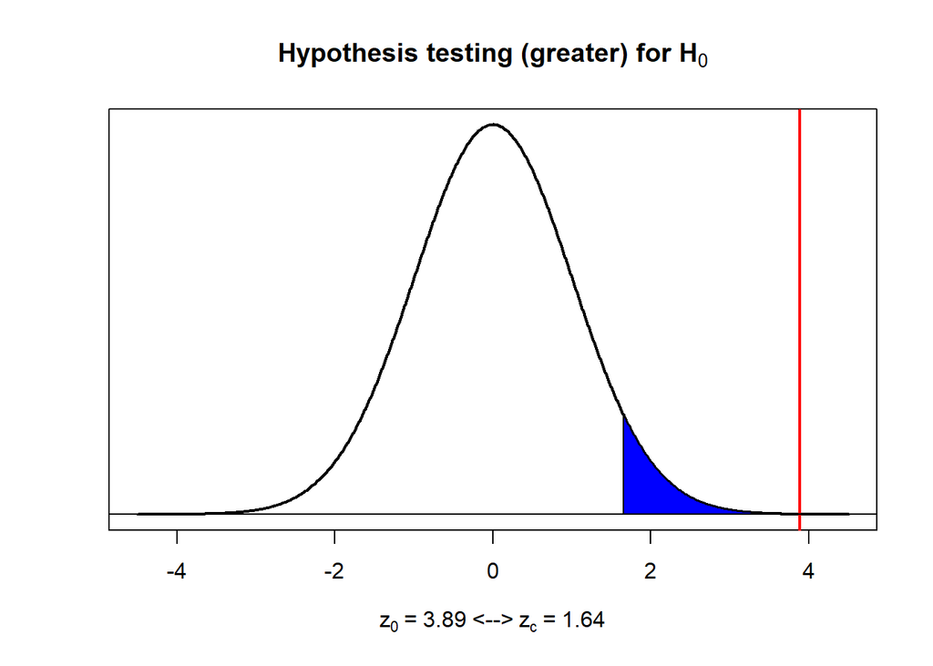

```r
#Use the plot.hypothesis function to plot the hypothesis test
plotmean.hypothesis(z0,zc,type='z',alt='g')
```

```r
#Define true difference in population means, and compute the power of the test with pwr.norm.test function:
delta<-(xbar24-xbar25)
d<-(delta-delta0)/sqrt(sigma1^2+sigma2^2)
pwr.norm.test(d,n1,0.05,alt='g')
```

```
##
##      Mean power calculation for normal distribution with known variance
##
##               d = 0.5997
##               n = 42
##       sig.level = 0.05
##           power = 0.9875
##     alternative = greater
```

```r
#We can also compute the type II error and power of the test manually:
beta <- pnorm(zc-((delta-delta0)/sed)); beta
```

```
## [1] 0.01249
```

```r
power<-1-beta; power
```

```
## [1] 0.9875
```

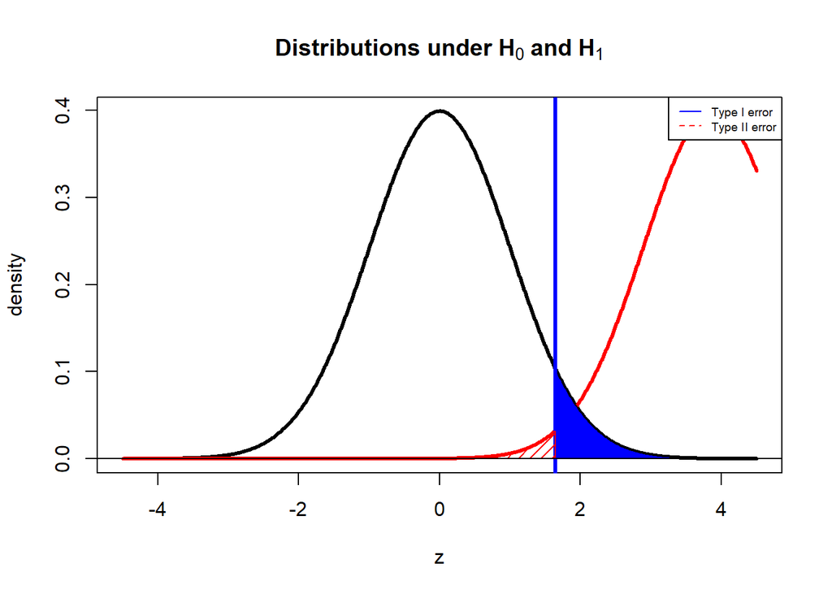

```r
#We can use our plotbeta function with the required parameters:
plotmean.beta(sed,zc,delta,n=1,type='z',alt='g')
```

```r
#In the second part, we need to determine the required sample size
#Again, we can use the pwr.norm.test function as seen below:
pwr.norm.test(d,n=NULL,0.05,power=0.90,alt='g')
```

```
##
##      Mean power calculation for normal distribution with known variance
##
##               d = 0.5997
##               n = 23.81
##       sig.level = 0.05
##           power = 0.9
##     alternative = greater
```

```r
#We can calculate the required sample size also manually.
#The parameters beta and zbeta are determined.
beta2 <- 0.10
zbeta <-qnorm(1-beta2); zbeta
```

```
## [1] 1.282
```

```r
#The required sample size is calculated.
nreq<-((zc+zbeta)/d)^2; nreq
```

```
## [1] 23.81
```

```r
ceiling(nreq)
```

```
## [1] 24
```

…

#### 3.2.2.4. Hypothesis Tests on the Ratio of Population Variances of Two Samples

F test was applied since two populations are independent and populations perform normal distribution for testing on the ratio of population variances of two samples. …

```r
#Write your codes here. Their results will appear after knitting the markdown file.

"FOR PERSONNEL EXPENDITURES AND OTHER CURRENT EXPENDITURES"
```

```
## [1] "FOR PERSONNEL EXPENDITURES AND OTHER CURRENT EXPENDITURES"
```

```r
#We want to test the null hypothesis H0: sigma1^2=sigma2^2 against the one-sided (greater) alternative.
#Define problem data.
var1<-var(data_22$PE)
var2<-var(data_22$OCE)
n1<-42
n2<-42
alpha<-0.05

#Find the upper and lower critical values
fcup <- qf(alpha/2,n1-1,n2-1,lower=F); fcup
```

```
## [1] 1.86
```

```r
fclo <- qf(1-alpha/2,n1-1,n2-1,lower=F); fclo
```

```
## [1] 0.5375
```

```r
#Calculate the test statistic
f0 <- (var1/var2); f0
```

```
## [1] 28.57
```

```r
#Give a decision with our testvar.cv function
testvar.cv(fclo,fcup,f0,theta0=1,alpha=0.05,alt='g')
```

```
## [1] "H0: sigma^2 = 1 is rejected at 0.05 significance level"
```

```r
#Calculate the p-value and give a decision with our test.pval function
pval <- pf(f0,n1-1,n2-1); pval
```

```
## [1] 1
```

```r
#Alternatively, we can use var.test() built-in function.
var.test(data_22$PE,data_22$OCE,alt='g')
```

```
##
##  F test to compare two variances
##
## data:  data_22$PE and data_22$OCE
## F = 29, num df = 41, denom df = 41, p-value <0.0000000000000002
## alternative hypothesis: true ratio of variances is greater than 1
## 95 percent confidence interval:
##  16.99   Inf
## sample estimates:
## ratio of variances
##              28.57
```

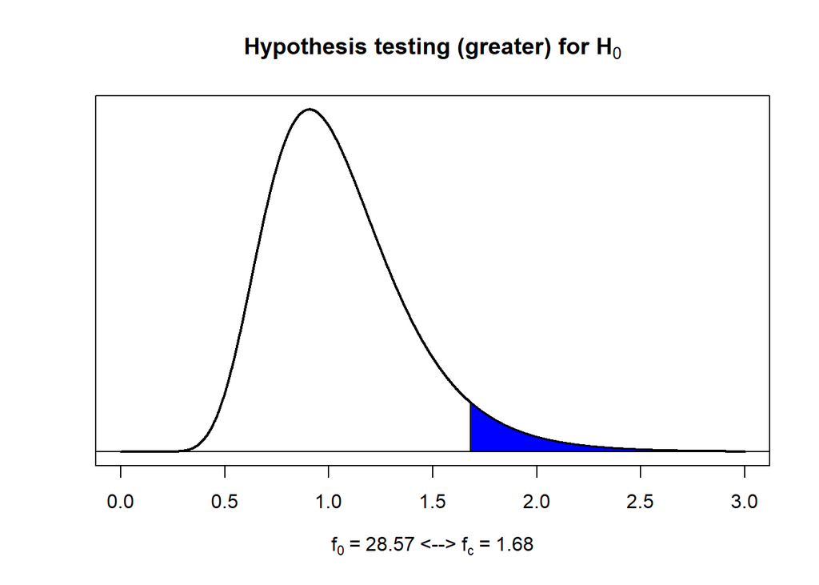

```r
#Use our plotvar.hypothesis function to plot the hypothesis test
plotvar.hypothesis(f0,alpha,df1=n1-1,df2=n2-1,type='f',alt='g')
```

```r
"FOR TEST ON PERSONNEL EXPENDITURES AND OTHER CURRENT EXPENDITURES "
```

```
## [1] "FOR TEST ON PERSONNEL EXPENDITURES AND OTHER CURRENT EXPENDITURES "
```

```r
#Define scale parameter and compute the power of the test with our power.var.test() function:
lambda <- 0.5
power.var.test(n1,lambda,sig.level=0.05,power=NULL,type="t",alt="o")
```

```
##
##      Two-sample F Variance test power calculation
##
##               n = 42
##          lambda = 0.5
##       sig.level = 0.05
##           power = 0.9967
##     alternative = one.sided
##
## NOTE: n is number in *each* group
```

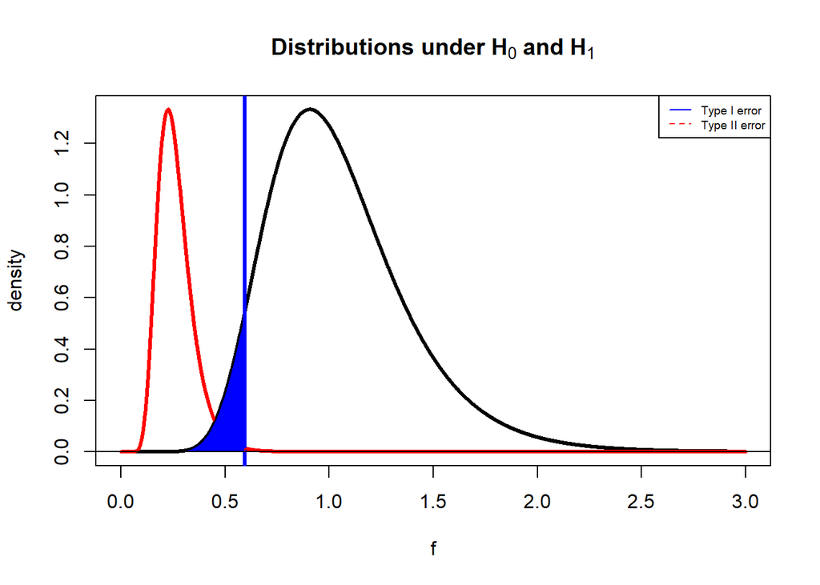

```r
#We can use our plotvar.beta function with the required parameters:
plotvar.beta(lambda,alpha,n1-1,n2-1,type='f',alt='o')
```

```r
"FOR PERSONNEL EXPENDITURES AND DEFENCE"
```

```
## [1] "FOR PERSONNEL EXPENDITURES AND DEFENCE"
```

```r
#We want to test the null hypothesis H0: sigma1^2=sigma2^2 against the one-sided (greater) alternative.
#Define problem data.
var1<-var(data_22$PE)
var3<-var(data_22$D)
n1<-42
n2<-42
alpha<-0.05



#Calculate the test statistic
f1 <- (var1/var3); f1
```

```
## [1] 36.75
```

```r
#Give a decision with our testvar.cv function
testvar.cv(fclo,fcup,f1,theta0=1,alpha=0.05,alt='g')
```

```
## [1] "H0: sigma^2 = 1 is rejected at 0.05 significance level"
```

```r
#Calculate the p-value and give a decision with our test.pval function
pval1 <- pf(f1,n1-1,n2-1); pval1
```

```
## [1] 1
```

```r
#Alternatively,--e can use var.test() built-in function.
var.test(data_22$PE,data_22$D,alt='g')
```

```
##
##  F test to compare two variances
##
## data:  data_22$PE and data_22$D
## F = 37, num df = 41, denom df = 41, p-value <0.0000000000000002
## alternative hypothesis: true ratio of variances is greater than 1
## 95 percent confidence interval:
##  21.85   Inf
## sample estimates:
## ratio of variances
##              36.75
```

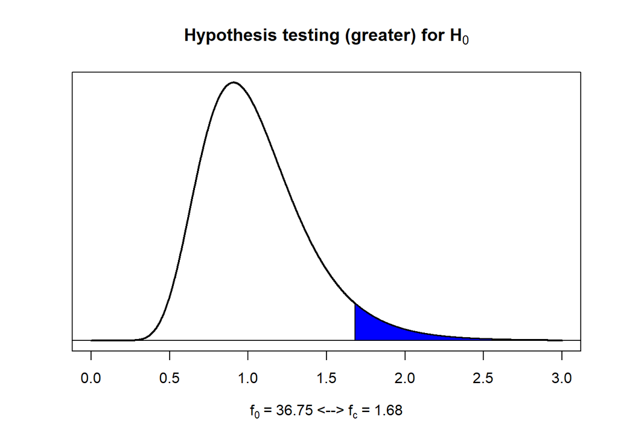

```r
#Use our plotvar.hypothesis function to plot the hypothesis test
plotvar.hypothesis(f1,alpha,df1=n1-1,df2=n2-1,type='f',alt='g')
```

```r
"FOR TEST ON PERSONNEL EXPENDITURES AND DEFENCE "
```

```
## [1] "FOR TEST ON PERSONNEL EXPENDITURES AND DEFENCE "
```

```r
#Define scale parameter and compute the power of the test with our power.var.test() function:
lambda1 <- 0.36
power.var.test(n1,lambda1,sig.level=0.05,power=NULL,type="t",alt="o")
```

```
##
##      Two-sample F Variance test power calculation
##
##               n = 42
##          lambda = 0.36
##       sig.level = 0.05
##           power = 1
##     alternative = one.sided
##
## NOTE: n is number in *each* group
```

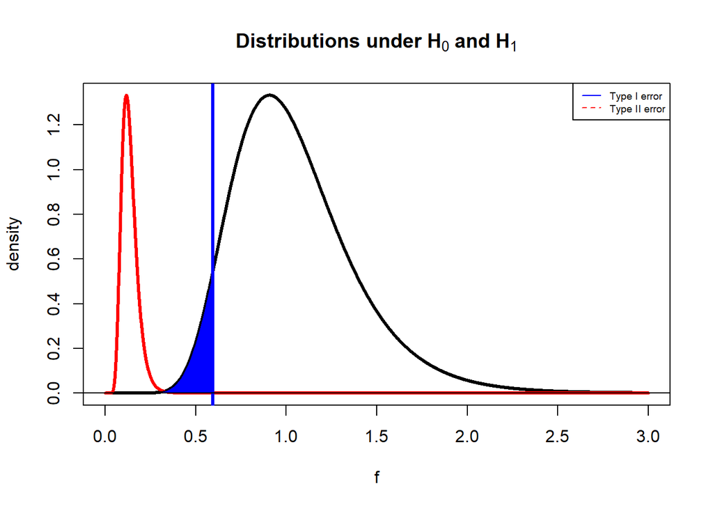

```r
#We can use our plotvar.beta function with the required parameters:
plotvar.beta(lambda1,alpha,n1-1,n2-1,type='f',alt='o')
```

```r
"FOR OTHER CURRENT EXPENDITURES AND DEFENCE"
```

```
## [1] "FOR OTHER CURRENT EXPENDITURES AND DEFENCE"
```

```r
#We want to test the null hypothesis H0: sigma1^2=sigma2^2 against the one-sided (greater) alternative.
#Define problem data.
var2<-var(data_22$OCE)
var3<-var(data_22$D)
n1<-42
n2<-42
alpha<-0.05



#Calculate the test statistic
f2 <- (var2/var3); f2
```

```
## [1] 1.286
```

```r
#Give a decision with our testvar.cv function
testvar.cv(fclo,fcup,f2,theta0=1,alpha=0.05,alt='g')
```

```
## [1] "H0: sigma^2 = 1 is not rejected at 0.05 significance level"
```

```r
#Calculate the p-value and give a decision with our test.pval function
pval2 <- pf(f2,n1-1,n2-1); pval2
```

```
## [1] 0.7881
```

```r
#Alternatively, we can use var.test() built-in function.
var.test(data_22$OCE,data_22$D,alt='g')
```

```
##
##  F test to compare two variances
##
## data:  data_22$OCE and data_22$D
## F = 1.3, num df = 41, denom df = 41, p-value = 0.2
## alternative hypothesis: true ratio of variances is greater than 1
## 95 percent confidence interval:
##  0.7649    Inf
## sample estimates:
## ratio of variances
##              1.286
```

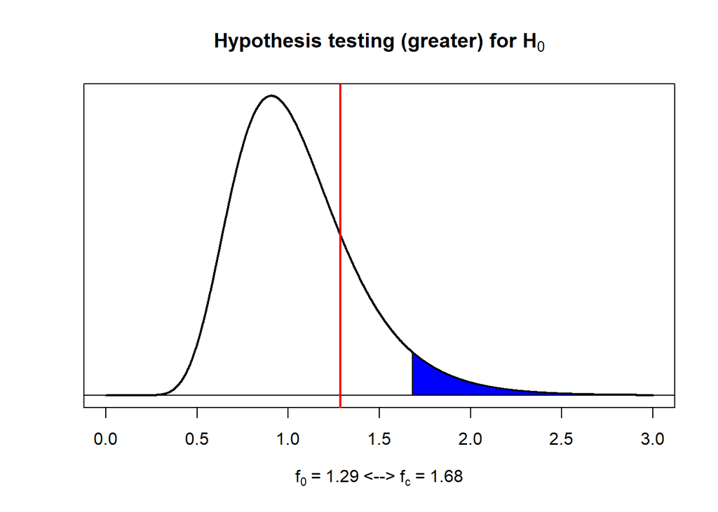

```r
#Use our plotvar.hypothesis function to plot the hypothesis test
plotvar.hypothesis(f2,alpha,df1=n1-1,df2=n2-1,type='f',alt='g')
```

```r
"FOR TEST ON OTHER CURRENT EXPENDITURES AND DEFENCE "
```

```
## [1] "FOR TEST ON OTHER CURRENT EXPENDITURES AND DEFENCE "
```

```r
#Define scale parameter and compute the power of the test with our power.var.test() function:
lambda2 <- 1
power.var.test(n1,lambda2,sig.level=0.05,power=NULL,type="t",alt="o")
```

```
##
##      Two-sample F Variance test power calculation
##
##               n = 42
##          lambda = 1
##       sig.level = 0.05
##           power = 0.05
##     alternative = one.sided
##
## NOTE: n is number in *each* group
```

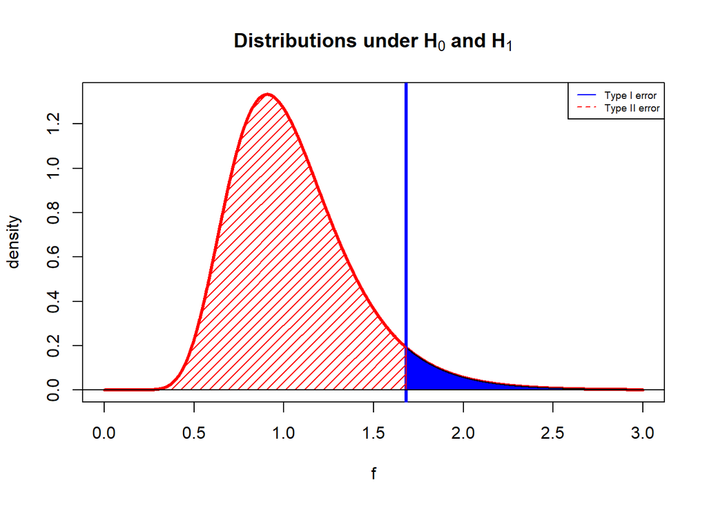

```r
#We can use our plotvar.beta function with the required parameters:
plotvar.beta(lambda2,alpha,n1-1,n2-1,type='f',alt='o')
```

```r
"FOR DEFENCE AND CURRENT EXPENDITURES "
```

```
## [1] "FOR DEFENCE AND CURRENT EXPENDITURES "
```

```r
#We want to test the null hypothesis H0: sigma1^2=sigma2^2 against the one-sided (less) alternative.
#Define problem data.
var3<-var(data_22$D)
var4<-var(data_22$CE)
n1<-42
n2<-42
alpha<-0.05

#Find the critical value
fc <- qf(1-alpha,n1-1,n2-1,lower=F); fc
```

```
## [1] 0.5947
```

```r
#Calculate the test statistic
f3 <- (var3/var4); f3
```

```
## [1] 0.01932
```

```r
#Give a decision with our testvar.cv function
testvar.cv(fc,cvup=NULL,f3,theta0=1,alpha=0.05,alt='l')
```

```
## [1] "H0: sigma^2 = 1 is rejected at 0.05 significance level"
```

```r
#Calculate the p-value and give a decision with our test.pval function
pval3 <- pf(f3,n1-1,n2-1); pval3
```

```
## [1] 0.0000000000000000000000004717
```

```r
test.pval(pval3,1,alpha,theta='sigma^2')
```

```
## [1] "H0: sigma^2 = 1 is rejected at 0.05 significance level"
```

```r
#Alternatively, we can use var.test() built-in function.
var.test(data_22$D,data_22$CE,alt='l')
```

```
##
##  F test to compare two variances
##
## data:  data_22$D and data_22$CE
## F = 0.019, num df = 41, denom df = 41, p-value <0.0000000000000002
## alternative hypothesis: true ratio of variances is less than 1
## 95 percent confidence interval:
##  0.00000 0.03249
## sample estimates:
## ratio of variances
##            0.01932
```

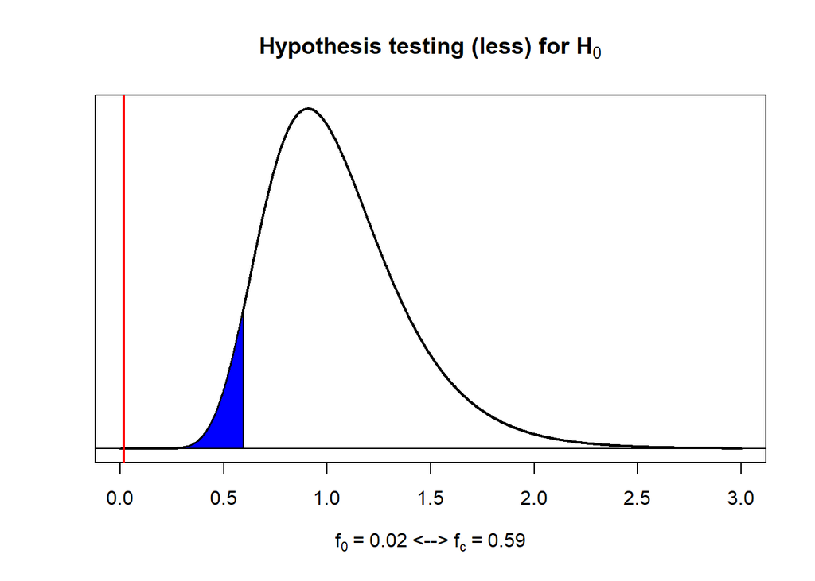

```r
#Use our plotvar.hypothesis function to plot the hypothesis test
plotvar.hypothesis(f3,alpha,df1=n1-1,df2=n2-1,type='f',alt='l')
```

```r
"FOR TEST ON DEFENCE AND CURRENT EXPENDITURES "
```

```
## [1] "FOR TEST ON DEFENCE AND CURRENT EXPENDITURES "
```

```r
#Define scale parameter and compute the power of the test with our power.var.test() function:
lambda3 <- 2
power.var.test(n1,lambda3,sig.level=0.05,power=NULL,type="t",alt="o")
```

```
##
##      Two-sample F Variance test power calculation
##
##               n = 42
##          lambda = 2
##       sig.level = 0.05
##           power = 0.9967
##     alternative = one.sided
##
## NOTE: n is number in *each* group
```

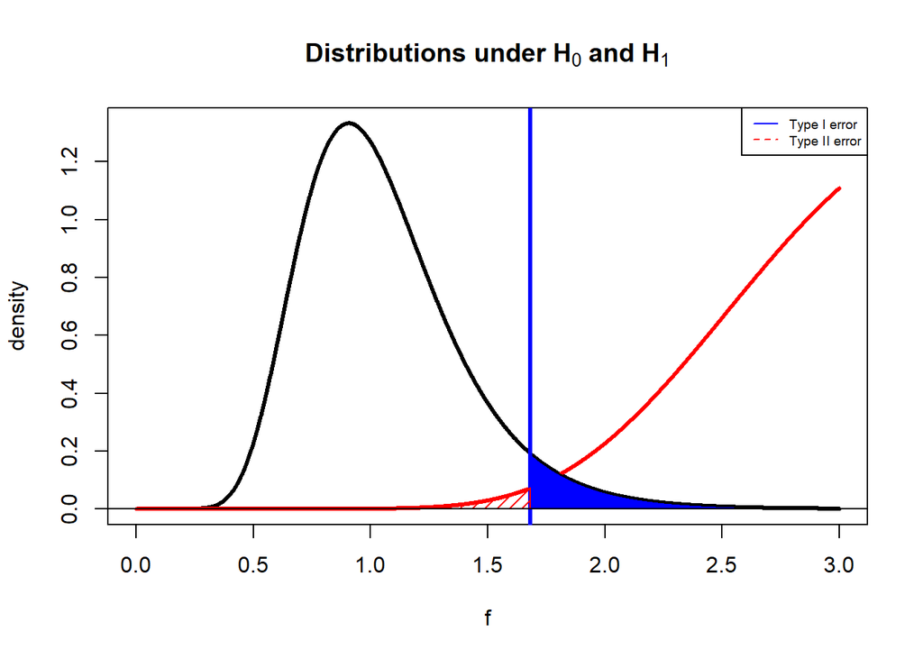

```r
#We can use our plotvar.beta function with the required parameters:
plotvar.beta(lambda3,alpha,n1-1,n2-1,type='f',alt='o')
```

…

### 3.2.3. Goodness of Fit Tests and Contingency Analyses

The goodness of fit test is used to determine whether sample data are consistent with a hypothesized distribution. If X2 is greater than critical value, the null hypothesis will be rejected …

```r
#For current expenditures

k <- 7
xbar <- mean(data_22$CE)
sd <- sd(data_22$CE)
z <- qnorm(0:k/k); z
```

```
## [1]    -Inf -1.0676 -0.5659 -0.1800  0.1800  0.5659  1.0676     Inf
```

```r
interval <- xbar+z*sd; interval
```

```
## [1]       -Inf -235190413   94815757  348715079  585567641  839466964 1169473133
## [8]        Inf
```

```r
gftCE<-(data_22$CE)
gftCE.breaks <- seq(650,2340682000,by=293000000)
gftCE.cut<- cut(gftCE,gftCE.breaks,right = F)
gftCE.freq<- table((gftCE.cut))
gftCE.freq
```

```
##
##      [650,2.93e+08) [2.93e+08,5.86e+08) [5.86e+08,8.79e+08) [8.79e+08,1.17e+09)
##                  26                   3                   1                   5
## [1.17e+09,1.47e+09) [1.47e+09,1.76e+09) [1.76e+09,2.05e+09)
##                   2                   3                   1
```

```r
#Plot the probabilities of each cell from standard normal distribution with k=7 equal bins.
x <- seq(-2,2,0.01)
plot(x,dnorm(x),type="l",yaxt='n',xlab='z',ylab='')
abline(v = z, col = "blue")
```

[output not shown]

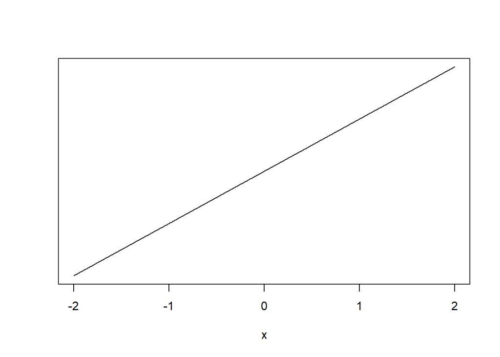

```r
#Plot the probabilities of each cell from normal distribution with k=7 equal bins.
plot(x,dnorm(x, xbar, sd),type="l",yaxt='n',ylab='')
abline(v = interval, col = "blue")
```

```r
#Observed frequencies of class i are entered into a table and expected frequencies are calculated for pi=1/7.
cut<-cut(0, interval, right=F)
voltage.freq<- c(26,3,1,5,2,3,1)
names(voltage.freq)<-levels(cut)
voltage.prob<-rep(1/k,k)
n<-42
voltage.exp<-n*voltage.prob

#View the observed and expected frequencies together.
cbind(Observed=voltage.freq,Expected=voltage.exp)
```

```
##                      Observed Expected
## [-Inf,-2.35e+08)           26        6
## [-2.35e+08,9.48e+07)        3        6
## [9.48e+07,3.49e+08)         1        6
## [3.49e+08,5.86e+08)         5        6
## [5.86e+08,8.39e+08)         2        6
## [8.39e+08,1.17e+09)         3        6
## [1.17e+09, Inf)             1        6
```

```r
#We do the Goodness of Fit test with 7-2-1=4 degrees of freedom since two parameters of normal dist. is estimated.
#We need to readjust the degrees of freedom by using the following functions.
voltage.Xsq<-chisq.test(voltage.freq,p=voltage.prob)
voltage.Xsq$parameter <- c(df=4)
voltage.Xsq$p.value <- pchisq(voltage.Xsq$statistic, df=4, lower=F)

#We can view the result of the test, observed and expected frequencies.
voltage.Xsq
```

```
##
##  Chi-squared test for given probabilities
##
## data:  voltage.freq
## X-squared = 83, df = 4, p-value <0.0000000000000002
```

```r
voltage.table<-rbind(observed=voltage.Xsq$observed, expected=voltage.Xsq$expected); t(voltage.table)
```

```
##                      observed expected
## [-Inf,-2.35e+08)           26    5.857
## [-2.35e+08,9.48e+07)        3    5.857
## [9.48e+07,3.49e+08)         1    5.857
## [3.49e+08,5.86e+08)         5    5.857
## [5.86e+08,8.39e+08)         2    5.857
## [8.39e+08,1.17e+09)         3    5.857
## [1.17e+09, Inf)             1    5.857
```

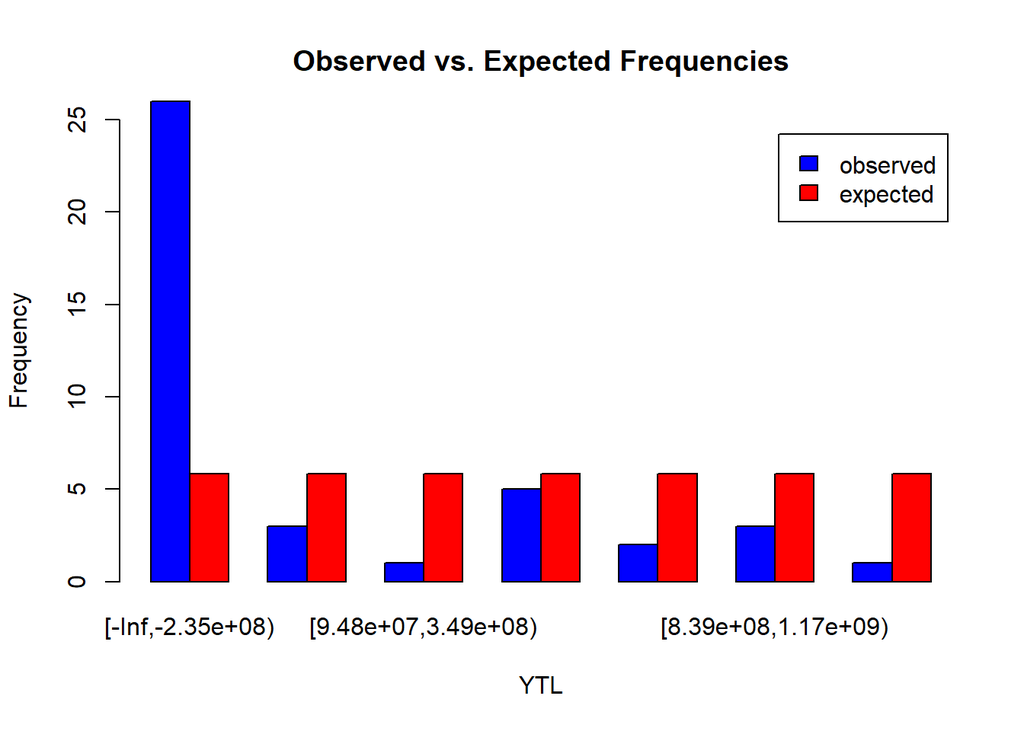

```r
barplot(voltage.table,ylim=c(0,25),beside=TRUE,legend=TRUE,main="Observed vs. Expected Frequencies",col=c("blue", "red"),xlab="YTL", ylab="Frequency")
```

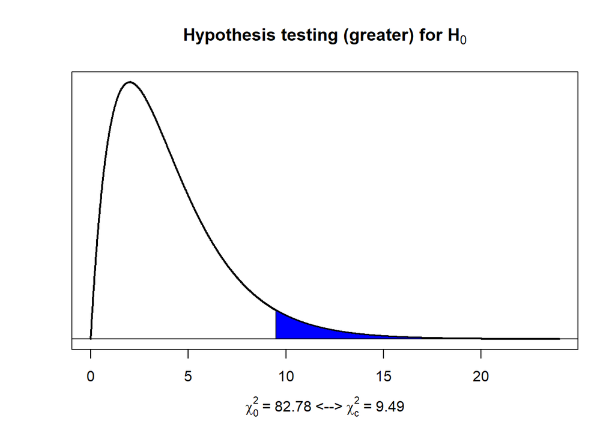

```r
#We can plot the hypothesis testing for goodness of fit using plotvar.hypothesis function that we defined before.
plotvar.hypothesis(voltage.Xsq$statistic,alpha=0.05,df1=4,type='c',alt='g')
```

```r
#Write your codes here. Their results will appear after knitting the markdown file.

#For Personnel expenditures

k <- 7
xbar <- mean(data_22$PE)
sd <- sd(data_22$PE)
z <- qnorm(0:k/k); z
```

```
## [1]    -Inf -1.0676 -0.5659 -0.1800  0.1800  0.5659  1.0676     Inf
```

```r
interval <- xbar+z*sd; interval
```

```
## [1]       -Inf -197741139   80352906  294312208  493906317  707865619  985959665
## [8]        Inf
```

```r
gftPE<-(data_22$CE)
gftPE.breaks <- seq(550,1965616054,by=245702000)
gftPE.cut<- cut(gftPE,gftPE.breaks,right = F)
gftPE.freq<- table((gftPE.cut))
gftPE.freq
```

```
##
##      [550,2.46e+08) [2.46e+08,4.91e+08) [4.91e+08,7.37e+08) [7.37e+08,9.83e+08)
##                  26                   2                   1                   2
## [9.83e+08,1.23e+09) [1.23e+09,1.47e+09) [1.47e+09,1.72e+09)
##                   5                   2                   2
```

```r
#Plot the probabilities of each cell from standard normal distribution with k=7 equal bins.
x <- seq(-2,2,0.01)
plot(x,dnorm(x),type="l",yaxt='n',xlab='z',ylab='')
abline(v = z, col = "blue")
```

```r
#Plot the probabilities of each cell from normal distribution with k=7 equal bins.
plot(x,dnorm(x, xbar, sd),type="l",yaxt='n',ylab='')
abline(v = interval, col = "blue")
```

```r
#Observed frequencies of class i are entered into a table and expected frequencies are calculated for pi=1/7.
cut<-cut(0, interval, right=F)
voltage.freq<- c(26,2,1,2,5,2,2)
names(voltage.freq)<-levels(cut)
voltage.prob<-rep(1/k,k)
n<-42
voltage.exp<-n*voltage.prob

#View the observed and expected frequencies together.
cbind(Observed=voltage.freq,Expected=voltage.exp)
```

```
##                      Observed Expected
## [-Inf,-1.98e+08)           26        6
## [-1.98e+08,8.04e+07)        2        6
## [8.04e+07,2.94e+08)         1        6
## [2.94e+08,4.94e+08)         2        6
## [4.94e+08,7.08e+08)         5        6
## [7.08e+08,9.86e+08)         2        6
## [9.86e+08, Inf)             2        6
```

```r
#We do the Goodness of Fit test with 7-2-1=4 degrees of freedom since two parameters of normal dist. is estimated.
#We need to readjust the degrees of freedom by using the following functions.
voltage.Xsq<-chisq.test(voltage.freq,p=voltage.prob)
voltage.Xsq$parameter <- c(df=4)
voltage.Xsq$p.value <- pchisq(voltage.Xsq$statistic, df=4, lower=F)

#We can view the result of the test, observed and expected frequencies.
voltage.Xsq
```

```
##
##  Chi-squared test for given probabilities
##
## data:  voltage.freq
## X-squared = 86, df = 4, p-value <0.0000000000000002
```

```r
voltage.table<-rbind(observed=voltage.Xsq$observed, expected=voltage.Xsq$expected); t(voltage.table)
```

```
##                      observed expected
## [-Inf,-1.98e+08)           26    5.714
## [-1.98e+08,8.04e+07)        2    5.714
## [8.04e+07,2.94e+08)         1    5.714
## [2.94e+08,4.94e+08)         2    5.714
## [4.94e+08,7.08e+08)         5    5.714
## [7.08e+08,9.86e+08)         2    5.714
## [9.86e+08, Inf)             2    5.714
```

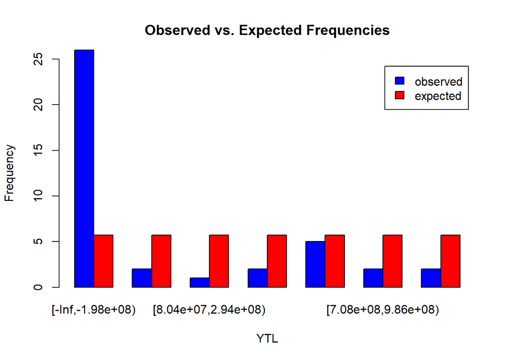

```r
barplot(voltage.table,ylim=c(0,25),beside=TRUE,legend=TRUE,main="Observed vs. Expected Frequencies",col=c("blue", "red"),xlab="YTL", ylab="Frequency")
```

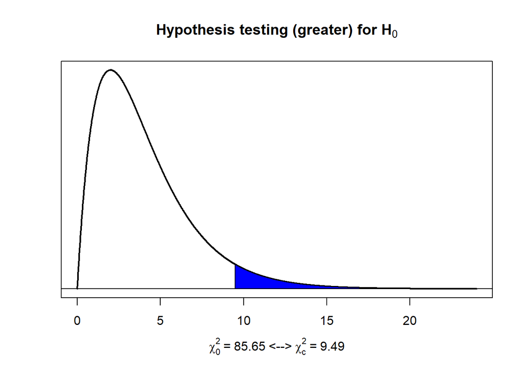

```r
#We can plot the hypothesis testing for goodness of fit using plotvar.hypothesis function that we defined before.
plotvar.hypothesis(voltage.Xsq$statistic,alpha=0.05,df1=4,type='c',alt='g')
```

```r
#Write your codes here. Their results will appear after knitting the markdown file.

#For Other Current expenditures

k <- 7
xbar <- mean(data_22$OCE)
sd <- sd(data_22$OCE)
z <- qnorm(0:k/k); z
```

```
## [1]    -Inf -1.0676 -0.5659 -0.1800  0.1800  0.5659  1.0676     Inf
```

```r
interval <- xbar+z*sd; interval
```

```
## [1]      -Inf -37691308  14334542  54362059  91702136 131729654 183755503
## [8]       Inf
```